# ggplot exercise

Johnny Chiu

2017/9/11

# Setup

```r
library(tidyverse)
library(babynames)
```

```r
data(babynames)

babynames <- mutate(babynames, initial=substr(name, 1, 1))
initial_props <- group_by(babynames, year, sex, initial) %>%
  summarize(count=sum(n), totalprop=sum(prop)) %>%
  ungroup()

topnames<-babynames %>%
  filter(year>=1950) %>%
  dplyr::group_by(name) %>%
  dplyr::summarize(total=sum(n)) %>%
  arrange(desc(total)) %>%
  head(1000) %>%
  inner_join(babynames, by='name') %>%
  filter(year >= 1950) %>%
  mutate(sex=recode(sex, "F"="Female", "M"="Male")) %>%
  dplyr::group_by(name, sex, total) %>%
  dplyr::summarize(sextotal=sum(n)) %>%
  spread(key=sex, value=sextotal) %>%
  mutate(ratio=(Male-Female)/total)
```

# Exercise 1

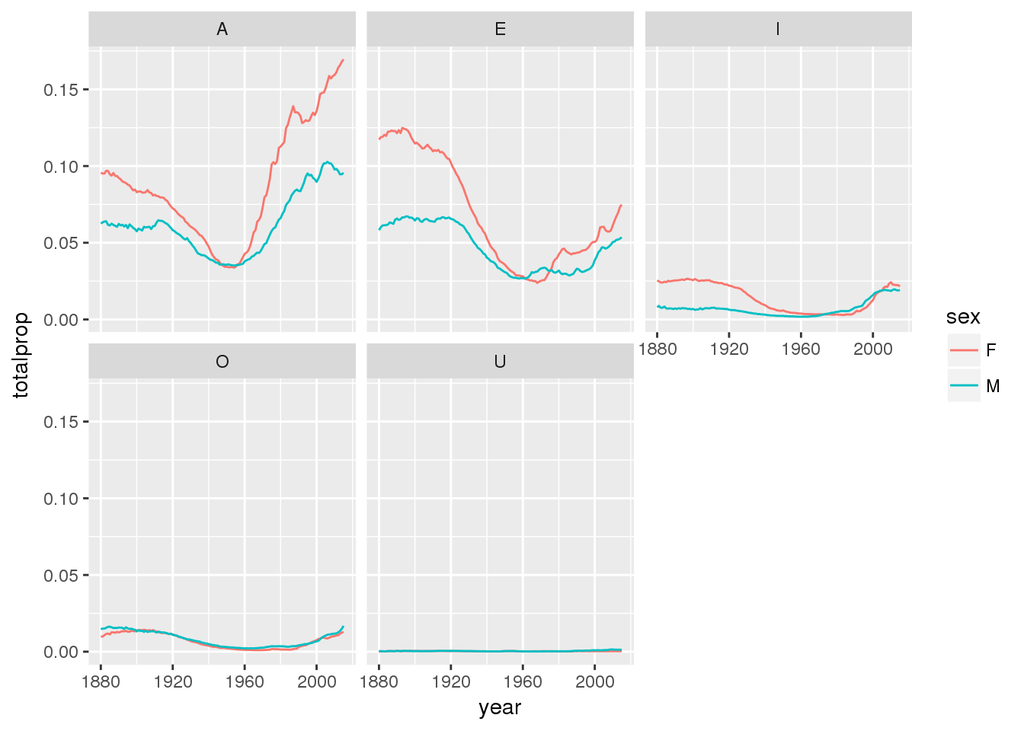

```r
initial_props <- dplyr::group_by(babynames, year, sex, initial) %>%
  dplyr::summarize(count=sum(n), totalprop=sum(prop))

initial_props %>%
  filter(initial %in% c('A','E','I','O','U')) %>%
  ggplot(aes(x=year, y=totalprop, color=sex)) +
  facet_wrap(~initial) +
  geom_line()
```

Part 2: Then change the plot to a stacked area plot so you can see the total number of names starting with vowels over time. Hint: find the correct geom to use, then look at the help to find the option to make it stacked. Hint 2: the aesthetic color refers to line or marker color. fill may be useful instead.

Note: The facet labels are pulled automatically from the names of the variable after it’s coverted to a factor. To change the labels (or the order of the groups), you can change the factor. This is a little tricky. The answer will include this code, but you may want to leave those labels as is for now. Another option is to use a labeller function.

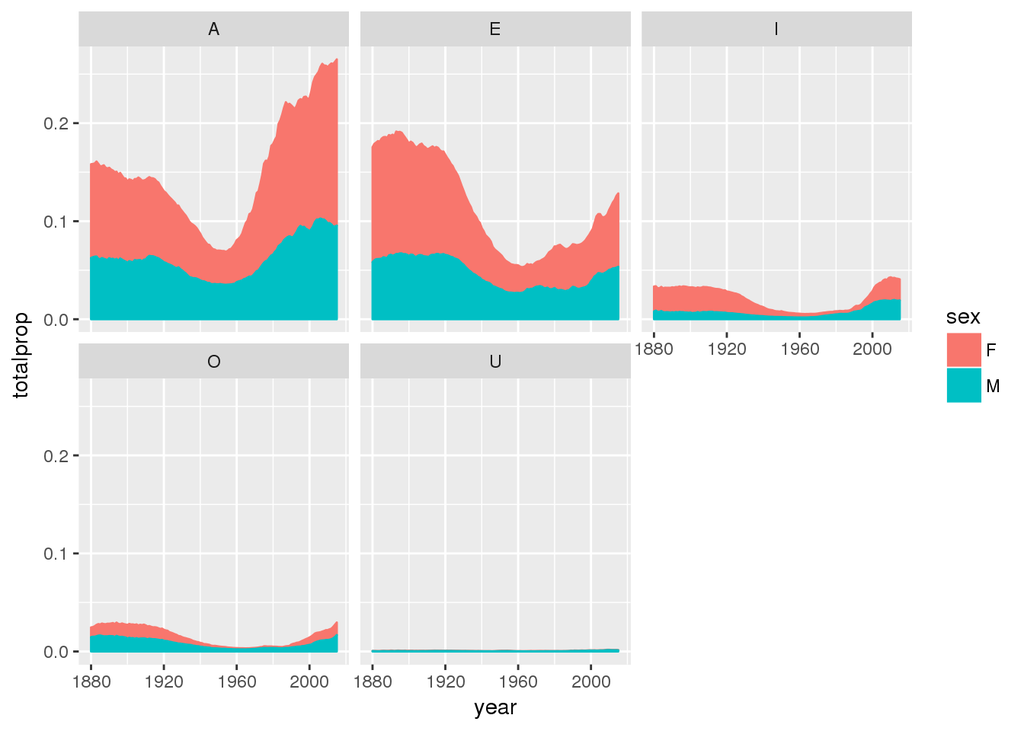

```r
initial_props %>%
  filter(initial %in% c('A','E','I','O','U')) %>%
  ggplot(aes(x=year, y=totalprop, color=sex, fill=sex)) +
  facet_wrap(~initial) +
  geom_area()
```

# Exercise 2

Using topnames, make another scatterplot, but filter out names that aren’t unisex (use ratio and set the cutoff youself). Change the size (the area, not the radius) of the points to be scaled according to the total number of people with the name. Fix the legend title. Set the x and y axes to have the same limits. Apply a theme of your choice to the plot.

Hint: you need an option at the bottom of the scales section on the ggplot2 cheatsheet.

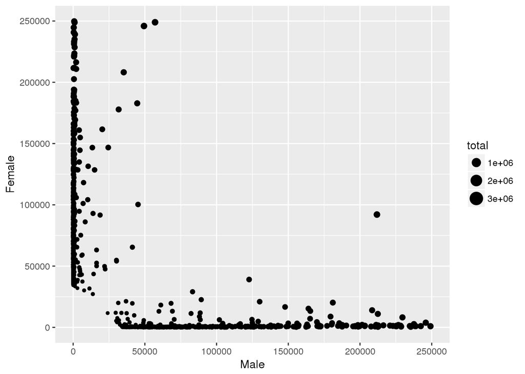

```r
library(ggthemes)
topnames %>%
  dplyr::filter(abs(ratio) > .2 & !is.na(ratio)) %>%
  ggplot(aes(x=Male, y=Female)) +
  geom_point(aes(size=total)) +
  lims(x=c(0,250000),y=c(0,250000))
```

# Exercise 3: Visualization and Missing Observations

This exercise is a bit more about data manipulation than visualization, but getting your data in the correct format is a crucial part of making a good plot.

In the first example in the plotly workshop materials, we look at names that start with A, divided by their second letter. For names with uncommon second letters, there might be a 0 for some years, so we might be missing some years in our data. On the scale of the initial plot, this isn’t a big deal. If we were looking at uncommon names, it might be.

1. Make a plot of the 5 most uncommon A? female names over time. Plot both a line and a point for each observation. Are there any years with data missing for any of the A? combinations?

```r
babynames <- mutate(babynames, first2=substr(name, 1, 2))
most_uncommon <- babynames %>%
  filter(initial=="A" & sex=='F') %>%
  group_by(first2) %>%
  summarise(count=n()) %>%
  arrange(count) %>%
  slice(1:5)

anames <- babynames %>%
  filter(first2 %in% most_uncommon$first2 & sex=='F') %>%
  dplyr::group_by(year, first2) %>%
  dplyr::summarize(count=sum(n), totalprop=sum(prop))

plot1<- anames %>%
  ggplot(aes(x=year, y=totalprop, color=first2)) +
  geom_line() +
  geom_point()
```

2. How can you check the data for these missing observations? (They aren’t missing values – they’re just not in the data.)

```r
x <- seq(1880,2015,by=1)
y <- as.character(most_uncommon$first2)
plot2 <- expand.grid(year=x,first2=y)
plot2 <- left_join(plot2, anames , by=c('year','first2'))
plot2_na <- plot2 %>% filter(is.na(count))
```

3. How can you fill in the missing values?

```r
plot2[is.na(plot2)] <- 0
```

4. Remake the plot in step 1 with the corrected data.

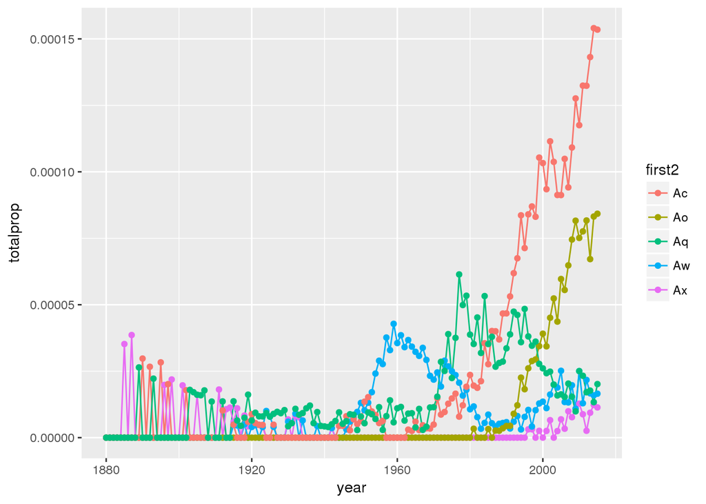

```r
plot2 %>%
  ggplot(aes(x=year, y=totalprop, color=first2)) +
  geom_line() +
  geom_point()
```